# HR data: fictional staff records

Capstone project: BIDA 302

Murilo Henrique Sisnando Rodrigues

## The scenario:

The fictional wholesale company, CR25 (for “Classic Rock 25”), currently has 999 employees.

### employee characteristics

The CSV file “df_HR_main.csv” contains the following variables:

- emp_id – a unique identification number for each employee
- start_date – the date the employee started their employment with CR25
- four variables based on the designated groups specified in Canada’s [*Employment Equity Act*](https://laws-lois.justice.gc.ca/eng/acts/E-5.401/), where “TRUE” indicates the the employee is a member of that group
  - women
  - Aboriginal peoples
  - persons with disabilities
  - members of visible minorities (meaning “persons, other than Aboriginal peoples, who are non-Caucasian in race or non-white in colour”).

### transaction history

Some of the employees in this company have been with the company since it started on 2010-01-01, and others started recently.

There are 5 occupations in the company, labelled A (for Apprentice) to E (for Executive), and each has more responsibility (and therefore pay) than the one below. Employees can start at any one of the occupations, and are eligible for a promotion after 90 days on the job (but some people take longer than that).

Each occupation has 3 steps (numbered 1 to 3); everyone starts at step 1, and moves to step 2 after 1 year in that occupation, and step 3 after 2 years.

The second CSV file “df_HR_transaction.csv” contains the promotion history for each employee. The variables are:

- emp_id – a unique identification number for each employee
- transaction_num – the hiring and promotion event categories
- transaction_date – the date of the hiring and promotion event
- occupation – the five occupation categories
- occ_step – the annual increment steps

### Your taks

You work in the human resources department, and need to make a summary for the company’s annual meeting. You will need to present tables and charts showing the hiring and promotion of staff within the occupational categories. To do this you will present summaries of the data with plots and tables.

### Project Starts here:

#### 1. Loading Libraries

```r
library(tidyverse)
library(dplyr)

library(scales)
library(lubridate)
library (janitor)
library(gganimate)


library(vtree)
```

#### 2. Importing data: csv

```r
HR_main <- read_csv("df_HR_main.csv")
HR_transaction <- read_csv("df_HR_transaction.csv")
HR_main
```

```
## # A tibble: 999 x 6
##    emp_id start_date equity_woman equity_visible_~ equity_aborigin~
##    <chr>  <date>     <lgl>        <lgl>            <lgl>
##  1 ID001  2010-01-02 TRUE         FALSE            FALSE
##  2 ID002  2010-01-03 TRUE         TRUE             TRUE
##  3 ID003  2010-01-08 FALSE        FALSE            TRUE
##  4 ID004  2010-01-10 TRUE         TRUE             FALSE
##  5 ID005  2010-01-16 TRUE         FALSE            FALSE
##  6 ID006  2010-01-17 TRUE         FALSE            FALSE
##  7 ID007  2010-01-21 TRUE         FALSE            FALSE
##  8 ID008  2010-01-25 FALSE        FALSE            FALSE
##  9 ID009  2010-01-27 TRUE         FALSE            FALSE
## 10 ID010  2010-01-30 TRUE         FALSE            FALSE
## # ... with 989 more rows, and 1 more variable: equity_disability <lgl>
```

```r
HR_transaction
```

```
## # A tibble: 2,997 x 5
##    emp_id transaction_num transaction_date occupation occ_step
##    <chr>  <chr>           <date>           <chr>         <dbl>
##  1 ID001  start_date      2010-01-02       D                 3
##  2 ID001  trans1          2019-12-20       E                 1
##  3 ID001  trans2          NA               <NA>             NA
##  4 ID002  start_date      2010-01-03       C                 3
##  5 ID002  trans1          2020-03-18       D                 1
##  6 ID002  trans2          2020-10-16       E                 1
##  7 ID003  start_date      2010-01-08       A                 3
##  8 ID003  trans1          2013-02-18       B                 1
##  9 ID003  trans2          2013-08-15       C                 3
## 10 ID004  start_date      2010-01-10       B                 3
## # ... with 2,987 more rows
```

*Use `distinct` to check that `HR_main$emp_id` is a primary key*

```r
HR_main %>%
  distinct(HR_main$emp_id)
```

```
## # A tibble: 999 x 1
##    `HR_main$emp_id`
##    <chr>
##  1 ID001
##  2 ID002
##  3 ID003
##  4 ID004
##  5 ID005
##  6 ID006
##  7 ID007
##  8 ID008
##  9 ID009
## 10 ID010
## # ... with 989 more rows
```

*Use `distinct` to check that `HR_transaction$emp_id` is a primary key*

```r
HR_transaction %>%
  distinct(HR_transaction$emp_id)
```

```
## # A tibble: 999 x 1
##    `HR_transaction$emp_id`
##    <chr>
##  1 ID001
##  2 ID002
##  3 ID003
##  4 ID004
##  5 ID005
##  6 ID006
##  7 ID007
##  8 ID008
##  9 ID009
## 10 ID010
## # ... with 989 more rows
```

*Using Lubridate to create a month/year column*

```r
HR_main <- HR_main %>%
  mutate(
    Month_Yr = format_ISO8601(start_date, precision = "ym"),
    Year = format_ISO8601(start_date, precision = "y")

  )

HR_main
```

```
## # A tibble: 999 x 8
##    emp_id start_date equity_woman equity_visible_~ equity_aborigin~
##    <chr>  <date>     <lgl>        <lgl>            <lgl>
##  1 ID001  2010-01-02 TRUE         FALSE            FALSE
##  2 ID002  2010-01-03 TRUE         TRUE             TRUE
##  3 ID003  2010-01-08 FALSE        FALSE            TRUE
##  4 ID004  2010-01-10 TRUE         TRUE             FALSE
##  5 ID005  2010-01-16 TRUE         FALSE            FALSE
##  6 ID006  2010-01-17 TRUE         FALSE            FALSE
##  7 ID007  2010-01-21 TRUE         FALSE            FALSE
##  8 ID008  2010-01-25 FALSE        FALSE            FALSE
##  9 ID009  2010-01-27 TRUE         FALSE            FALSE
## 10 ID010  2010-01-30 TRUE         FALSE            FALSE
## # ... with 989 more rows, and 3 more variables: equity_disability <lgl>,
## #   Month_Yr <chr>, Year <chr>
```

*Visualize - a draft plot*

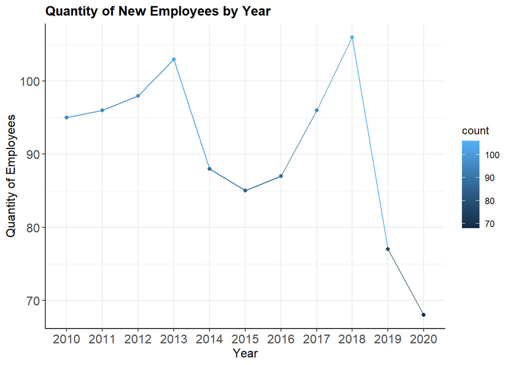

```r
HR_main %>%
   group_by(`Year`)%>%
   summarise(count=n())%>%
   ggplot(aes(x=Year, y=count, colour=count)) +
   geom_line(aes(group=1)) + geom_point() + theme_bw() +
   theme(
    panel.border = element_rect(colour="white"),
    plot.title = element_text(face="bold"),
    axis.line = element_line(colour="black"),
    axis.title = element_text(size=12),
    axis.text = element_text(size=12)
   )+
  labs(title = "Quantity of New Employees by Year",x= "Year", y= "Quantity of Employees")
```

*Visualize - a draft plot*

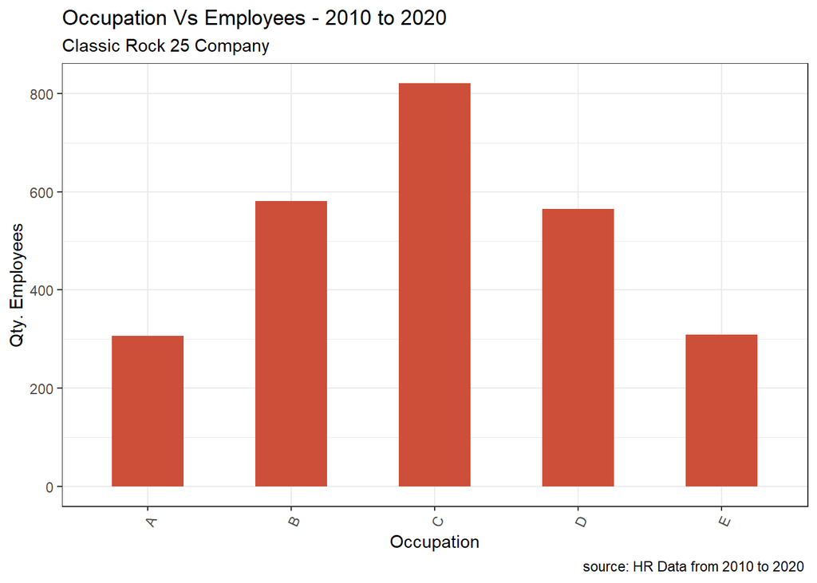

```r
theme_set(theme_bw())

HR <- inner_join(HR_main, HR_transaction, key = "emp_id")%>%
  filter(!is.na(occupation))%>%
   group_by(`occupation`)%>%
   summarise(count=n())%>%
   # Draw plot
  ggplot( aes(x=occupation, y=count)) +
  geom_bar(stat="identity", width=.5, fill="tomato3") +
  labs(title="Occupation Vs Employees - 2010 to 2020",
       subtitle="Classic Rock 25 Company ",
       caption="source: HR Data from 2010 to 2020 ",
       x = "Occupation", y = "Qty. Employees" ) +
  theme(axis.text.x = element_text(angle=65, vjust=0.6))
HR
```

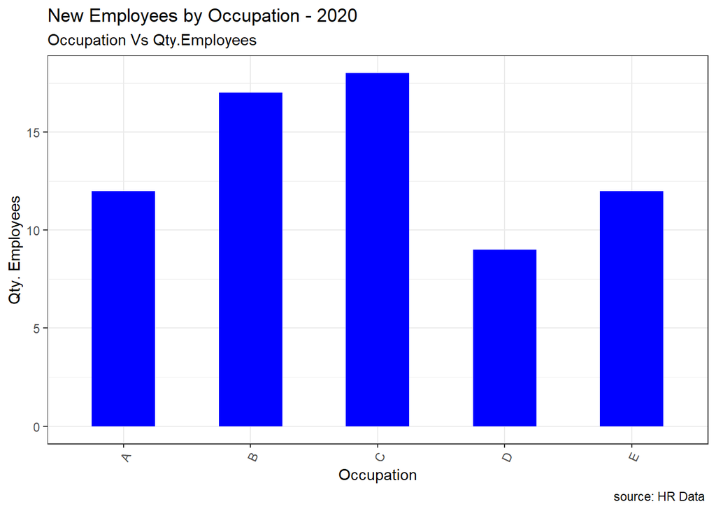

```r
theme_set(theme_bw())

HR <- inner_join(HR_main, HR_transaction, key = "emp_id")%>%
filter(!is.na(occupation),transaction_num == "start_date",Year==2020)%>%
   group_by(`occupation`)%>%
   summarise(count=n())%>%
   # Draw plot
  ggplot( aes(x=occupation, y=count)) +
  geom_bar(stat="identity", width=.5, fill="blue") +
  labs(title="New Employees by Occupation - 2020 ",
       subtitle="Occupation Vs Qty.Employees ",
       caption="source: HR Data ",
       x = "Occupation", y = "Qty. Employees" ) +
  theme(axis.text.x = element_text(angle=65, vjust=0.6))
HR
```

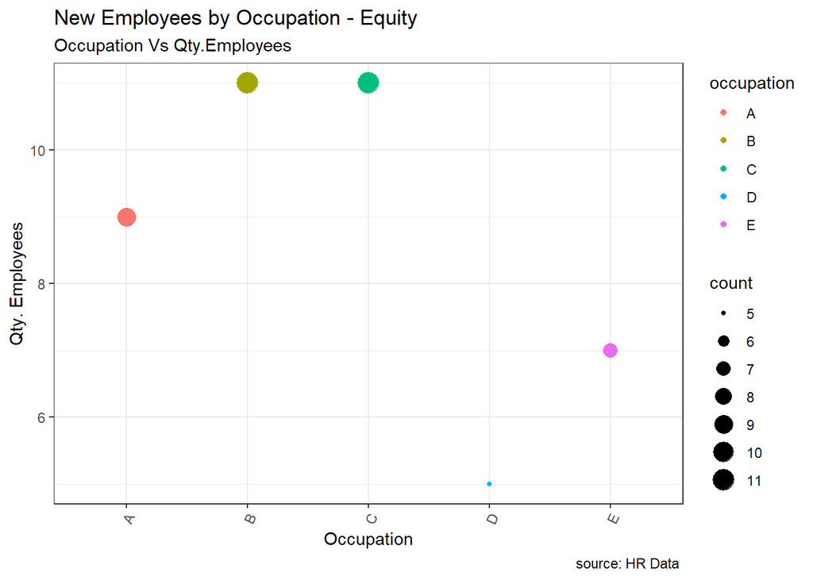

```r
theme_set(theme_bw())

HR <- inner_join(HR_main, HR_transaction, key = "emp_id")%>%
filter(!is.na(occupation),transaction_num == "start_date",Year==2020)%>%
  filter(equity_woman == "TRUE" | equity_visible_minority== "TRUE" | equity_aboriginal== "TRUE" | equity_disability== "TRUE")%>%
   group_by(`occupation`)%>%
   summarise(count=n())%>%
   # Draw plot
  ggplot( aes(x=occupation, y=count)) +
  geom_point(aes(col=occupation, size=count)) +
  labs(title="New Employees by Occupation - Equity ",
       subtitle="Occupation Vs Qty.Employees ",
       caption="source: HR Data ",
       x = "Occupation", y = "Qty. Employees" ) +
  theme(axis.text.x = element_text(angle=65, vjust=0.6))
HR
```

*Percentage of New Equity employees by year*

```r
HR2 <- inner_join(HR_main, HR_transaction, key = "emp_id")%>%
filter(!is.na(occupation),transaction_num == "start_date")%>%
  filter(equity_woman == "TRUE" | equity_visible_minority== "TRUE" | equity_aboriginal== "TRUE" | equity_disability== "TRUE")%>%
  tabyl(Year, occupation)%>%
  adorn_percentages("col") %>%
  adorn_pct_formatting()
HR2
```

```
##  Year     A     B     C     D     E
##  2010 11.1%  7.6% 11.1%  2.2%  5.9%
##  2011 12.0% 12.7%  8.5%  8.7%  5.9%
##  2012  6.2% 11.7%  9.8%  0.0%  0.0%
##  2013 12.5%  9.1% 10.6%  6.5%  5.9%
##  2014  8.7%  9.6%  9.4%  4.3%  0.0%
##  2015 12.5%  7.6%  5.1%  6.5%  5.9%
##  2016  7.2% 10.2% 10.6% 10.9%  0.0%
##  2017 11.5% 10.7%  8.9% 19.6%  0.0%
##  2018  6.7% 10.2% 12.8% 15.2%  5.9%
##  2019  7.2%  5.1%  8.5% 15.2% 29.4%
##  2020  4.3%  5.6%  4.7% 10.9% 41.2%
```

*Quantity o promotions by Occupation*

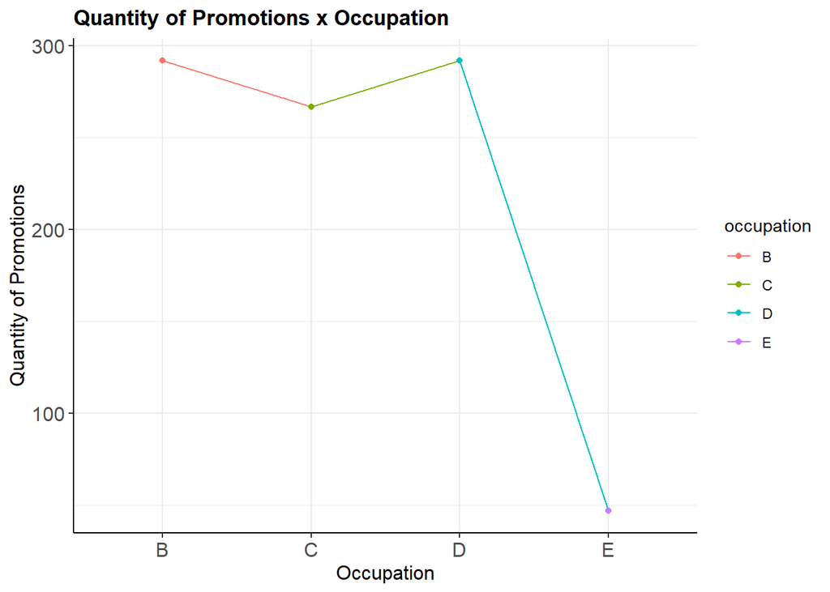

```r
HR3 <- inner_join(HR_main, HR_transaction, key = "emp_id")%>%
filter(!is.na(occupation) & !is.na(transaction_date))%>%
filter(transaction_num == "trans1" | transaction_num == "trans1")%>%
  group_by(`occupation`)%>%
   summarise(count=n())%>%
   # Draw plot
  ggplot(aes(x=occupation, y=count, colour=occupation)) +
   geom_line(aes(group=1)) + geom_point() + theme_bw() +
   theme(
    panel.border = element_rect(colour="white"),
    plot.title = element_text(face="bold"),
    axis.line = element_line(colour="black"),
    axis.title = element_text(size=12),
    axis.text = element_text(size=12)
   )+
  labs(title = "Quantity of Promotions x Occupation",x= "Occupation", y= "Quantity of Promotions")
HR3
```

```r
HR3 <- inner_join(HR_main, HR_transaction, key = "emp_id")%>%
filter(!is.na(occupation) & !is.na(transaction_date))%>%
filter(transaction_num == "trans1" | transaction_num == "trans1")%>%
  tabyl(Year, occupation)
HR3
```

```
##  Year  B  C  D E
##  2010 33 25 31 1
##  2011 31 27 32 4
##  2012 29 35 30 1
##  2013 38 29 31 3
##  2014 27 28 28 2
##  2015 31 26 20 3
##  2016 22 26 30 5
##  2017 35 22 27 9
##  2018 22 30 31 8
##  2019 16 13 23 9
##  2020  8  6  9 2
```